# Lesson 3

### What to Do First?

Notes: Read data and start with some basic look at the data: what is the format (head), what are the columns (head), what data do the columns have (str, summary). ***

### Pseudo-Facebook User Data

Notes:

```r
getwd()
```

```
## [1] "/home/tollek/workspace/personal/udacity-data-science/p4/l3"
```

```r
list.files()
```

```
## [1] "lesson3_student.html" "lesson3_student.rmd"  "pseudo_facebook.tsv"
```

```r
pf <- read.csv('pseudo_facebook.tsv', sep = '\t')
head(pf)
```

```
##    userid age dob_day dob_year dob_month gender tenure friend_count
## 1 2094382  14      19     1999        11   male    266            0
## 2 1192601  14       2     1999        11 female      6            0
## 3 2083884  14      16     1999        11   male     13            0
## 4 1203168  14      25     1999        12 female     93            0
## 5 1733186  14       4     1999        12   male     82            0
## 6 1524765  14       1     1999        12   male     15            0
##   friendships_initiated likes likes_received mobile_likes
## 1                     0     0              0            0
## 2                     0     0              0            0
## 3                     0     0              0            0
## 4                     0     0              0            0
## 5                     0     0              0            0
## 6                     0     0              0            0
##   mobile_likes_received www_likes www_likes_received
## 1                     0         0                  0
## 2                     0         0                  0
## 3                     0         0                  0
## 4                     0         0                  0
## 5                     0         0                  0
## 6                     0         0                  0
```

```r
summary(pf)
```

```
##      userid             age            dob_day         dob_year
##  Min.   :1000008   Min.   : 13.00   Min.   : 1.00   Min.   :1900
##  1st Qu.:1298806   1st Qu.: 20.00   1st Qu.: 7.00   1st Qu.:1963
##  Median :1596148   Median : 28.00   Median :14.00   Median :1985
##  Mean   :1597045   Mean   : 37.28   Mean   :14.53   Mean   :1976
##  3rd Qu.:1895744   3rd Qu.: 50.00   3rd Qu.:22.00   3rd Qu.:1993
##  Max.   :2193542   Max.   :113.00   Max.   :31.00   Max.   :2000
##
##    dob_month         gender          tenure        friend_count
##  Min.   : 1.000   female:40254   Min.   :   0.0   Min.   :   0.0
##  1st Qu.: 3.000   male  :58574   1st Qu.: 226.0   1st Qu.:  31.0
##  Median : 6.000   NA's  :  175   Median : 412.0   Median :  82.0
##  Mean   : 6.283                  Mean   : 537.9   Mean   : 196.4
##  3rd Qu.: 9.000                  3rd Qu.: 675.0   3rd Qu.: 206.0
##  Max.   :12.000                  Max.   :3139.0   Max.   :4923.0
##                                  NA's   :2
##  friendships_initiated     likes         likes_received
##  Min.   :   0.0        Min.   :    0.0   Min.   :     0.0
##  1st Qu.:  17.0        1st Qu.:    1.0   1st Qu.:     1.0
##  Median :  46.0        Median :   11.0   Median :     8.0
##  Mean   : 107.5        Mean   :  156.1   Mean   :   142.7
##  3rd Qu.: 117.0        3rd Qu.:   81.0   3rd Qu.:    59.0
##  Max.   :4144.0        Max.   :25111.0   Max.   :261197.0
##
##   mobile_likes     mobile_likes_received   www_likes
##  Min.   :    0.0   Min.   :     0.00     Min.   :    0.00
##  1st Qu.:    0.0   1st Qu.:     0.00     1st Qu.:    0.00
##  Median :    4.0   Median :     4.00     Median :    0.00
##  Mean   :  106.1   Mean   :    84.12     Mean   :   49.96
##  3rd Qu.:   46.0   3rd Qu.:    33.00     3rd Qu.:    7.00
##  Max.   :25111.0   Max.   :138561.00     Max.   :14865.00
##
##  www_likes_received
##  Min.   :     0.00
##  1st Qu.:     0.00
##  Median :     2.00
##  Mean   :    58.57
##  3rd Qu.:    20.00
##  Max.   :129953.00
##
```

### Histogram of Users’ Birthdays

Notes:

```r
# install.packages('ggplot2')
library(ggplot2)
library(ggthemes)
theme_set(theme_minimal())
names(pf)
```

```
##  [1] "userid"                "age"
##  [3] "dob_day"               "dob_year"
##  [5] "dob_month"             "gender"
##  [7] "tenure"                "friend_count"
##  [9] "friendships_initiated" "likes"
## [11] "likes_received"        "mobile_likes"
## [13] "mobile_likes_received" "www_likes"
## [15] "www_likes_received"
```

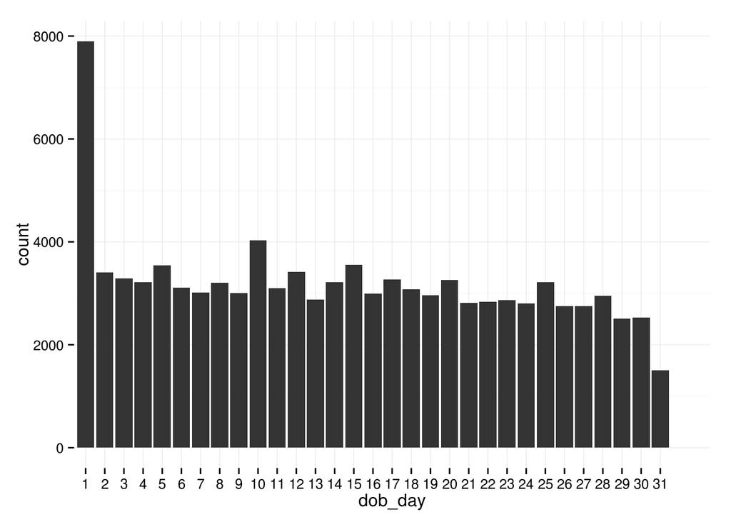

```r
# qplot(x = dob_day, data = pf)
ggplot(aes(x = dob_day), data = pf) +
  geom_histogram() +
  scale_x_discrete(breaks = 1:31)
```

#### What are some things that you notice about this histogram?

Response: - 1st has noticeably more counts that any other data. This is most likely due to fact, that some people don’t want to specify their birth date. To put sth in, they choose 1st - similar (but smaller) effect can be seen for 10th and 20th - they both have small spikes. - interesting, if the same situation happens for months (more January than any other) or years (any special year?) ***

### Moira’s Investigation

Notes: people significantly underestimate their audience size (estimate is usually 25% of real value).

### Estimating Your Audience Size

Notes: –

#### Think about a time when you posted a specific message or shared a photo on Facebook. What was it?

Response: –

#### How many of your friends do you think saw that post?

Response: –

#### Think about what percent of your friends on Facebook see any posts or comments that you make in a month. What percent do you think that is?

Response: –

### Perceived Audience Size

Notes: –

### Faceting

Notes:

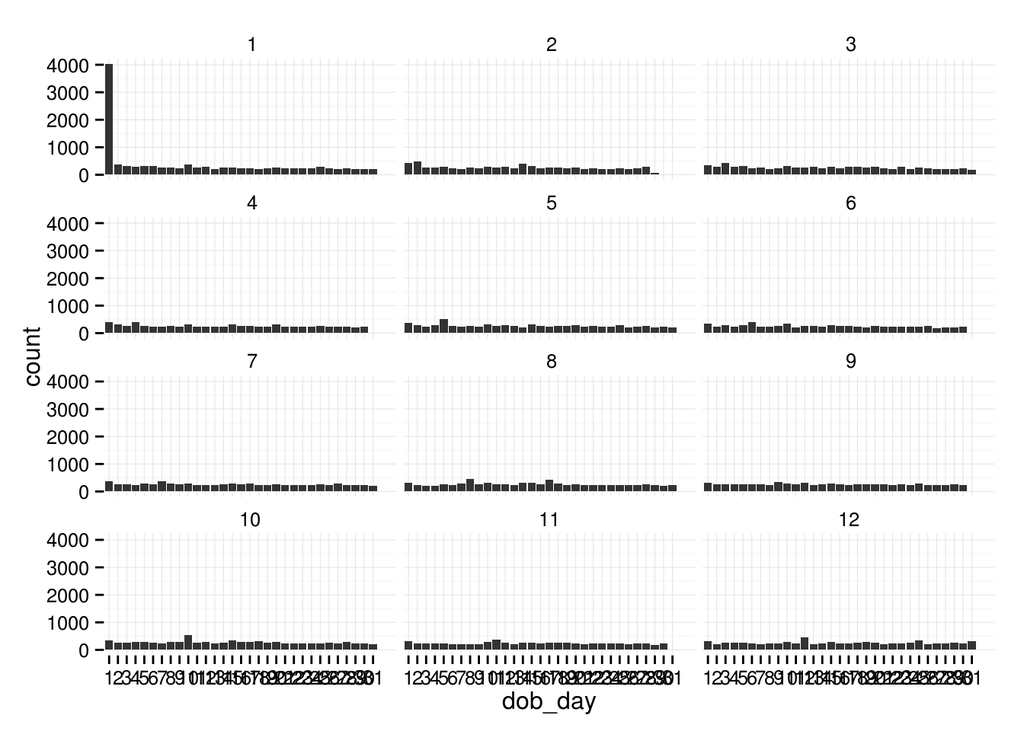

```r
ggplot(aes(x = dob_day), data = pf) +
  geom_histogram() +
  scale_x_discrete(breaks = 1:31) +
  facet_wrap(~dob_month, ncol = 3)
```

```r
# facet_wrap(formula)
# facet_wrap(~variable)
# use . to skip variable (http://www.cookbook-r.com/Graphs/Facets_(ggplot2)/)
# facet_grid(vertical ~ horizontal)
```

#### Let’s take another look at our plot. What stands out to you here?

Response: Jan 1st is significantly overrepresented. Other ‘1st’ days of month do not present such a big anomaly anymore.

### Be Skeptical - Outliers and Anomalies

Notes:

### Moira’s Outlier

Notes: histogram of estimated views had one outlier with estimated 10M views. This has clealry skewed the histogram by extending the X-axis.

#### Which case do you think applies to Moira’s outlier?

Response: bad data about extreme case.

### Friend Count

Notes:

#### What code would you enter to create a histogram of friend counts?

```
## stat_bin: binwidth defaulted to range/30. Use 'binwidth = x' to adjust this.
```

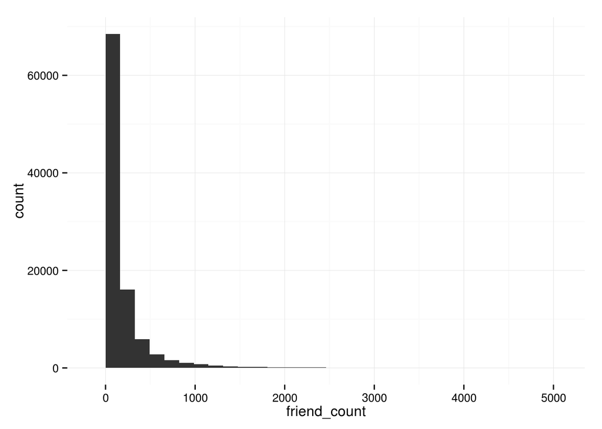

```r
ggplot(aes(x = friend_count), data = pf) +
  geom_histogram()
```

#### How is this plot similar to Moira’s first plot?

Response: there are some huge outliers (friend_count ~5000) that extend the X-axis making it hard to see what is happening with the bulk of data. This kind of distribution is called ‘Long-tail’ data.

### Limiting the Axes

Notes:

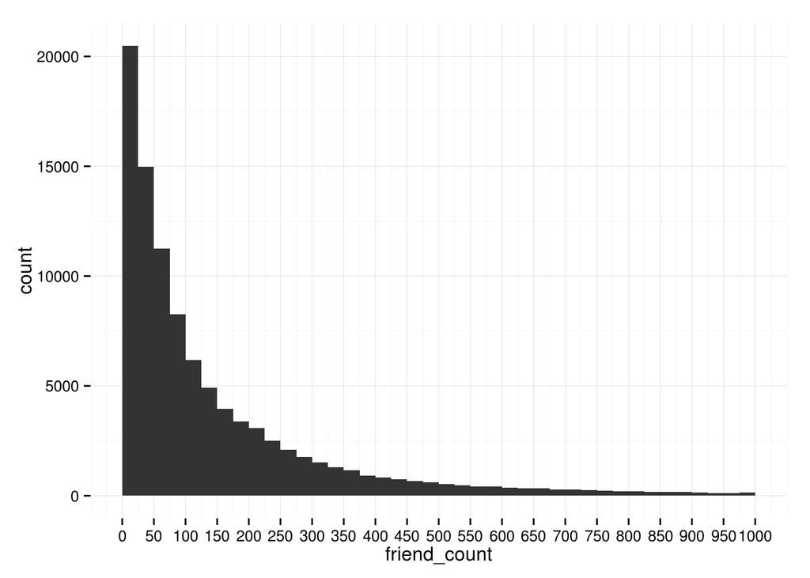

```r
ggplot(aes(x = friend_count), data = pf) +
  geom_histogram(binwidth = 25) +
  scale_x_continuous(limits = c(0, 1000), breaks = seq(0, 1000, 50))
```

### Exploring with Bin Width

Notes: people tend to guess round values (10, 20, 30, 50, 100). Setting the bin_width = 1 helps to reveal this pattern.

### Adjusting the Bin Width

Notes: many people have < 25 friends (or no friends at all, after setting bin_width = 1)

### Faceting Friend Count

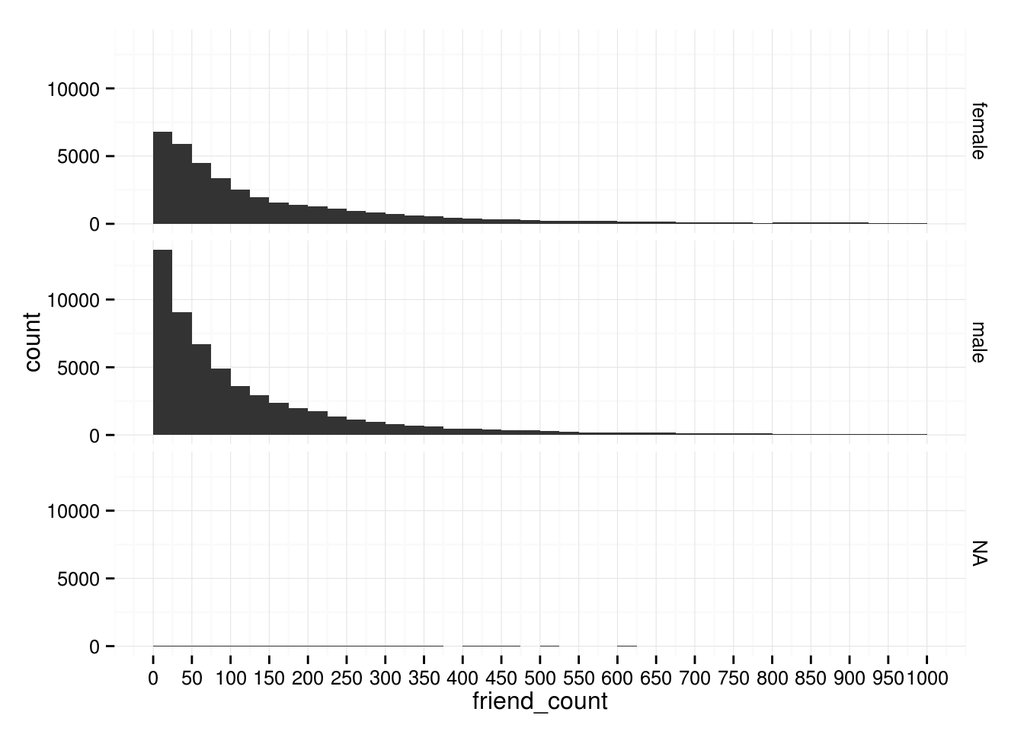

```r
# What code would you add to create a facet the histogram by gender?
# Add it to the code below.
ggplot(aes(x = friend_count), data = pf) +
  geom_histogram(binwidth = 25) +
  scale_x_continuous(limits = c(0, 1000), breaks = seq(0, 1000, 50)) +
  facet_grid(gender ~ .)
```

### Omitting NA Values

Notes: histogram do not answer the question clearly (‘Who has more firends: men or women?’).

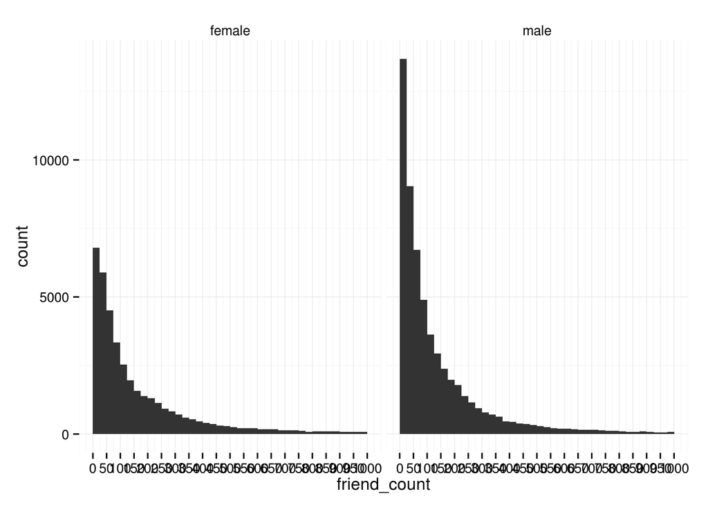

```r
ggplot(aes(x = friend_count), data = subset(pf, !is.na(gender))) +
  geom_histogram(binwidth = 25) +
  scale_x_continuous(limits = c(0, 1000), breaks = seq(0, 1000, 50)) +
  facet_wrap(~gender)
```

### Statistics ‘by’ Gender

Notes:

```r
table(pf$gender)
```

```
##
## female   male
##  40254  58574
```

```r
by(pf$friend_count, pf$gender, summary)
```

```
## pf$gender: female
##    Min. 1st Qu.  Median    Mean 3rd Qu.    Max.
##       0      37      96     242     244    4923
## --------------------------------------------------------
## pf$gender: male
##    Min. 1st Qu.  Median    Mean 3rd Qu.    Max.
##       0      27      74     165     182    4917
```

```r
# stats: who on average has more?
#y$female[4] - y$male[4]
# stats: median difference
#y$female[3] - y$male[3]
```

#### Who on average has more friends: men or women?

Response: women

#### What’s the difference between the median friend count for women and men?

Response:

#### Why would the median be a better measure than the mean?

Response:

### Tenure

Notes:

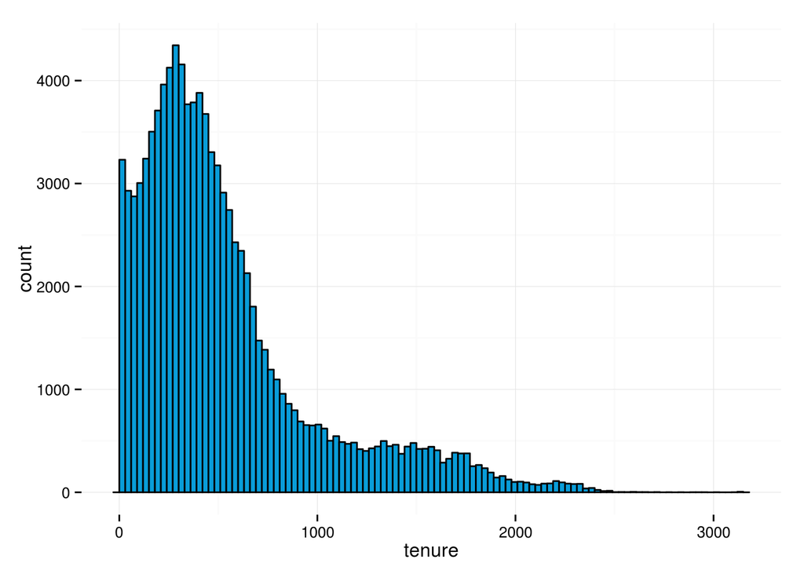

```r
ggplot(aes(x = tenure), data = pf) +
  geom_histogram(binwidth = 30, color = 'black', fill = '#099DD9')
```

#### How would you create a histogram of tenure by year?

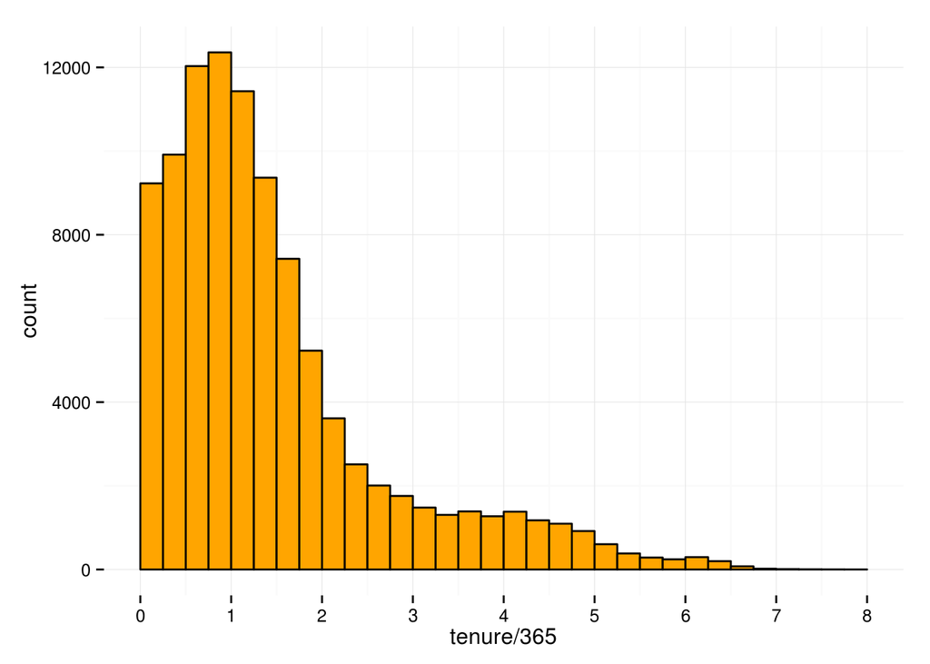

```r
ggplot(aes(x = tenure/365), data = pf) +
  geom_histogram(binwidth = 0.25, color = 'black', fill = 'orange') +
  scale_x_continuous(limits = c(0, 8), breaks = seq(0, 8,1))
```

### Labeling Plots

Notes:

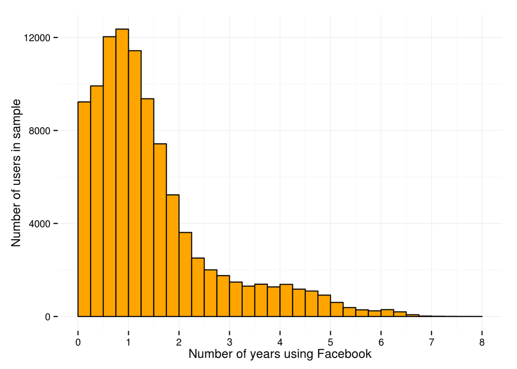

```r
ggplot(aes(x = tenure/365), data = pf) +
  geom_histogram(binwidth = 0.25, color = 'black', fill = 'orange') +
  scale_x_continuous(limits = c(0, 8), breaks = seq(0, 8,1)) +
  xlab('Number of years using Facebook') +
  ylab('Number of users in sample')
```

### User Ages

Notes:

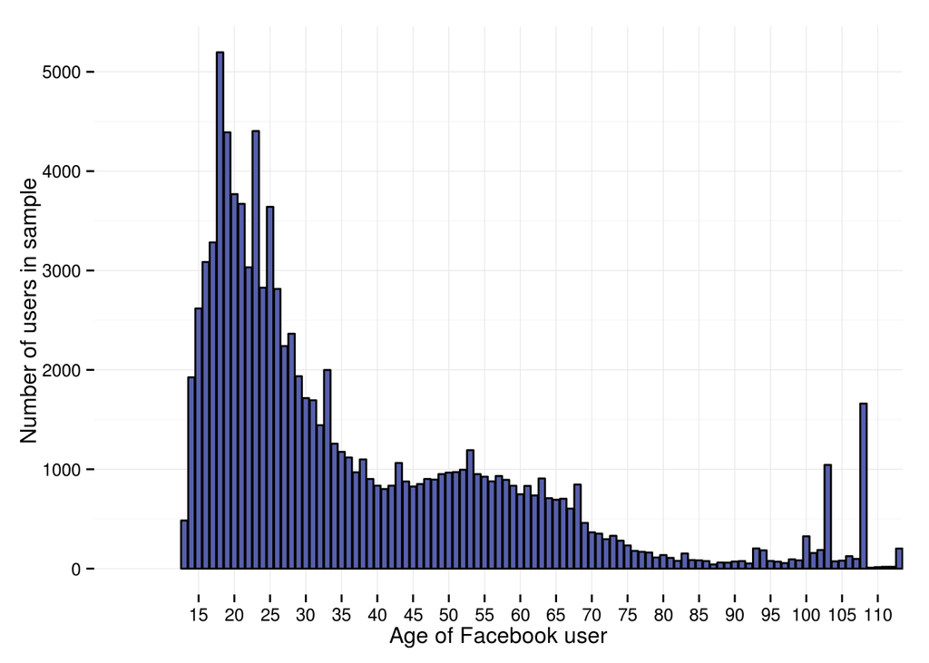

```r
ggplot(aes(x = age), data = pf) +
  geom_histogram(binwidth = 1, color = 'black', fill = '#5760AB') +
  #scale_x_continuous(limits = c(10, 120), breaks = seq(10, 113, 5)) +
  scale_x_discrete(breaks = seq(10, 113, 5)) +
  xlab('Age of Facebook user') +
  ylab('Number of users in sample')
```

#### What do you notice?

Response:

### The Spread of Memes

Notes: Lara’s site and Memes papers: http://www.ladamic.com/ http://www-personal.umich.edu/~ladamic/papers/memes/howmet.pdf

### Lada’s Money Bag Meme

Notes:

### Transforming Data

Notes:

### Add a Scaling Layer

Notes: create a plot with 3 histograms: untransformed friend_count, log10 and sqrt

```r
summary(pf$friend_count)
```

```
##    Min. 1st Qu.  Median    Mean 3rd Qu.    Max.
##     0.0    31.0    82.0   196.4   206.0  4923.0
```

```r
summary(log(pf$friend_count + 1))
```

```
##    Min. 1st Qu.  Median    Mean 3rd Qu.    Max.
##   0.000   3.466   4.419   4.301   5.333   8.502
```

```r
summary(sqrt(pf$friend_count + 1))
```

```
##    Min. 1st Qu.  Median    Mean 3rd Qu.    Max.
##   1.000   5.657   9.110  11.180  14.390  70.170
```

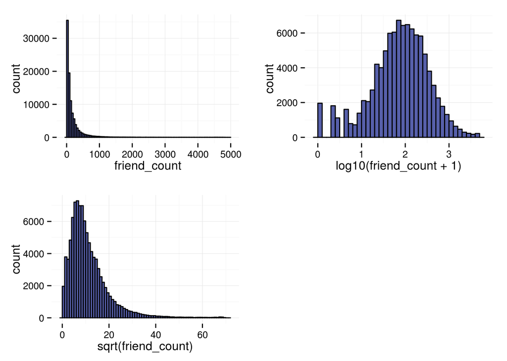

```r
# create a plot with 3 histograms: untransformed friend_count, log10 and sqrt
fc_reg <- ggplot(aes(x = friend_count), data = pf) +
  geom_histogram(binwidth = 50, color = 'black', fill = '#5760AB')
#fc_reg

fc_log <- ggplot(aes(x = log10(friend_count+1)), data = pf) +
  geom_histogram(binwidth = 0.1, color = 'black', fill = '#5760AB')
#fc_log

# alternatively, we can use scale_x_log()
#fc_log <- ggplot(aes(x = friend_count), data = pf) +
#  geom_histogram(binwidth = 0.1, color = 'black', fill = '#5760AB') +
#  scale_x_log10()
#fc_log

fc_sqrt <- ggplot(aes(x = sqrt(friend_count)), data = pf) +
  geom_histogram(binwidth = 1, color = 'black', fill = '#5760AB')
#fc_sqrt

library(gridExtra)
grid.arrange(fc_reg, fc_log, fc_sqrt, ncol=2)
```

### Frequency Polygons

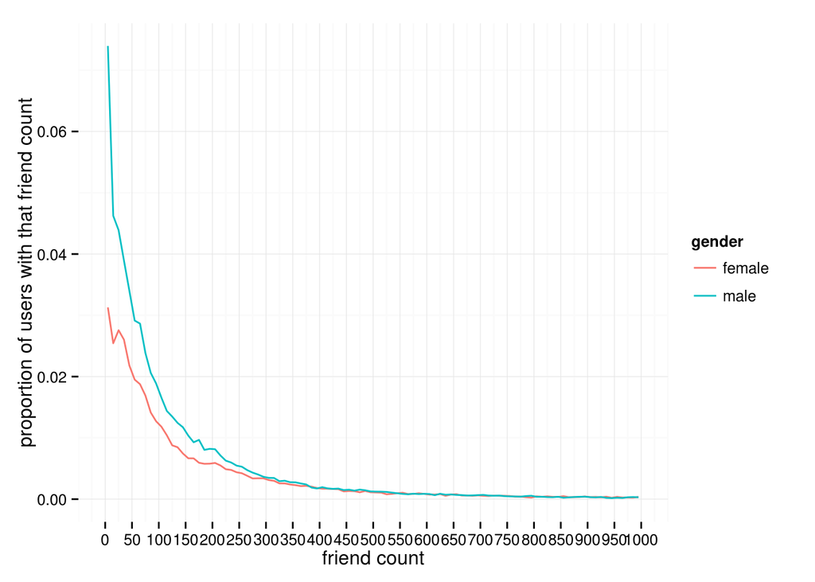

```r
ggplot(aes(x = friend_count, y = ..count../sum(..count..)), data = subset(pf, !is.na(gender))) +
  geom_freqpoly(aes(color = gender), binwidth=10) +
  scale_x_continuous(lim = c(0, 1000), breaks = seq(0, 1000, 50)) +
  xlab('friend count') +
  ylab('proportion of users with that friend count')
```

```r
# you can try y = ..density..
```

### Likes on the Web

Notes:

```
## stat_bin: binwidth defaulted to range/30. Use 'binwidth = x' to adjust this.
```

[figure not shown]

```r
ggplot(aes(x = www_likes, y = ..count..), data = subset(pf, !is.na(gender))) +
  geom_freqpoly(aes(color = gender)) +
  #geom_freqpoly(aes(color = gender), binwidth=0.5) +
  scale_x_continuous() +
  scale_x_log10() +
  xlab('likes count') +
  ylab('proportion of users with that likes count')
```

What’s the www_like count for males?

```
males <-pf[pf$gender == 'male' & !is.na(pf$gender),]
sum(males$www_likes)
females <- pf[pf$gender == 'female' & !is.na(pf$gender),]
sum(females$www_likes)

by(pf$www_likes, pf$gender, sum)
#pf$gender: female
#[1] 3507665
#-------------------------------------------------------------------------------------------------------
#pf$gender: male
#[1] 1430175
```

### Box Plots

Notes: http://flowingdata.com/2008/02/15/how-to-read-and-use-a-box-and-whisker-plot/ IQR (interquartile range): https://en.wikipedia.org/wiki/Interquartile_range

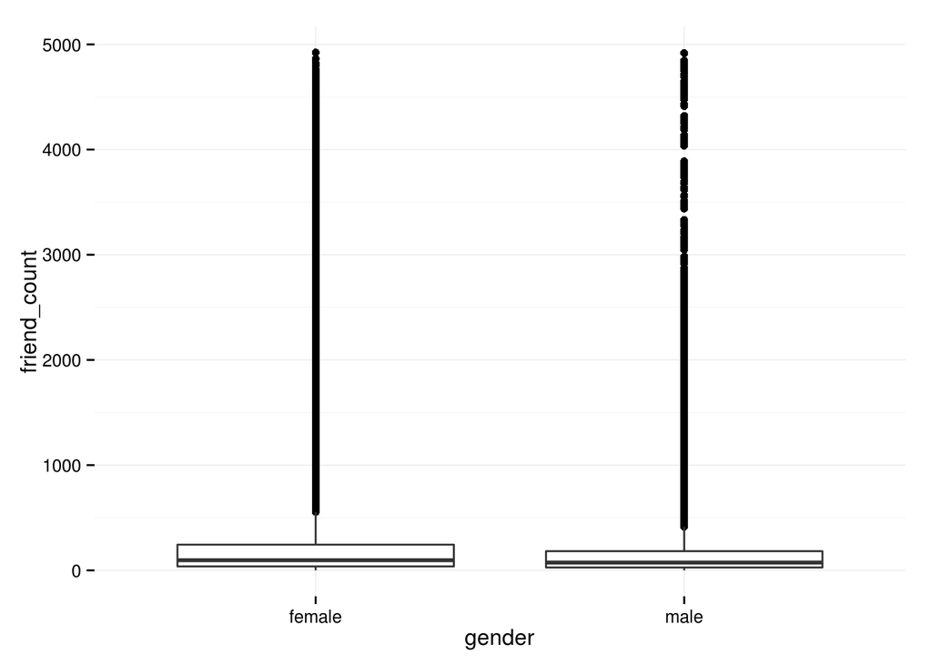

```r
ggplot(aes(x = gender, y = friend_count), data = subset(pf, !is.na(gender))) +
  geom_boxplot()
```

#### Adjust the code to focus on users who have friend counts between 0 and 1000.

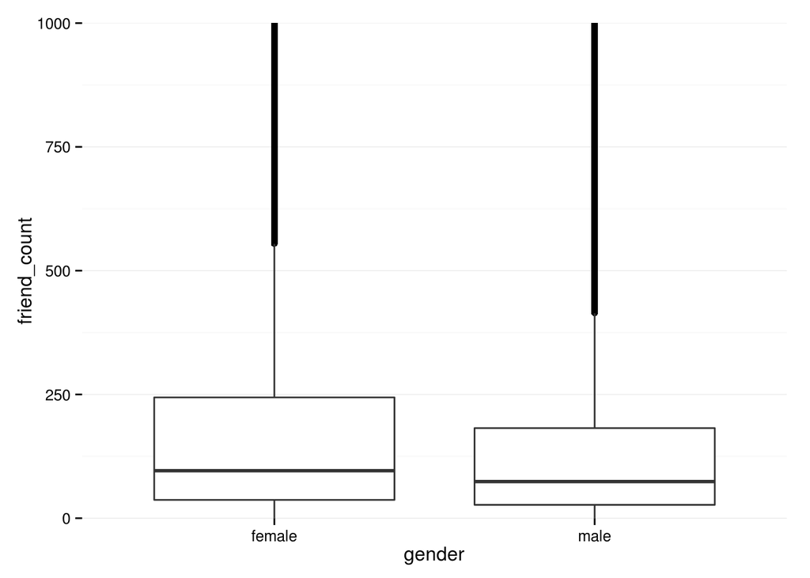

```r
ggplot(aes(x = gender, y = friend_count), data = subset(pf, !is.na(gender))) +
  # ylim drops ovbservations
  #ylim(0, 1000) +
  coord_cartesian(ylim = c(0, 1000)) +
  geom_boxplot()
```

```r
by(pf$friend_count, pf$gender, summary)
```

```
## pf$gender: female
##    Min. 1st Qu.  Median    Mean 3rd Qu.    Max.
##       0      37      96     242     244    4923
## --------------------------------------------------------
## pf$gender: male
##    Min. 1st Qu.  Median    Mean 3rd Qu.    Max.
##       0      27      74     165     182    4917
```

### Box Plots, Quartiles, and Friendships

Notes:

#### On average, who initiated more friendships in our sample: men or women?

```r
by(pf$friendships_initiated, pf$gender, summary)
```

```
## pf$gender: female
##    Min. 1st Qu.  Median    Mean 3rd Qu.    Max.
##     0.0    19.0    49.0   113.9   124.8  3654.0
## --------------------------------------------------------
## pf$gender: male
##    Min. 1st Qu.  Median    Mean 3rd Qu.    Max.
##     0.0    15.0    44.0   103.1   111.0  4144.0
```

Response:

### Getting Logical

Notes:

```r
summary(pf$mobile_likes)
```

```
##    Min. 1st Qu.  Median    Mean 3rd Qu.    Max.
##     0.0     0.0     4.0   106.1    46.0 25110.0
```

```r
summary(pf$mobile_likes > 0)
```

```
##    Mode   FALSE    TRUE    NA's
## logical   35056   63947       0
```

```r
mobile_check_in <- NA
pf$mobile_check_in <- ifelse(pf$mobile_likes > 0, 1, 0)
summary(pf$mobile_check_in)
```

```
##    Min. 1st Qu.  Median    Mean 3rd Qu.    Max.
##  0.0000  0.0000  1.0000  0.6459  1.0000  1.0000
```

```r
pf$mobile_check_in <- factor(pf$mobile_check_in)
summary(pf$mobile_check_in)
```

```
##     0     1
## 35056 63947
```

```r
# % of users that checked_in with mobile
sum(pf$mobile_check_in == 1) / length(pf$mobile_check_in) * 100
```

```
## [1] 64.59097
```

Response: 65% ***

### Analyzing One Variable

Reflection:

- grab the initial idea of the data with summary, str, head and other functions to have a feeling of the data
- understand types, distribution and anomalies of your variables
- experiment with breakdowns - does the variable differ when break down by date or gender?
- try to find out where the anomalies are coming from? is it just a single, extreme data point or is there a bigger story behind?
- make sure numbers and plots you create do answer the question. Change the axis, scales, limits or plot type to get stuff done ***

Click **KnitHTML** to see all of your hard work and to have an html page of this lesson, your answers, and your notes!